# Session 10: Data Science Capstone Project

Yiwei Zheng

2022-12-19

# Introduction and learning objectives

The purpose of this exercise is to build an estimation engine to guide investment decisions in London house market. You will first build machine learning algorithms (and tune them) to estimate the house prices given variety of information about each property. Then, using your algorithm, you will choose 200 houses to invest in out of about 2000 houses on the market at the moment.

**Learning objectives**

1. Using different data mining algorithms for prediction.
2. Dealing with large data sets
3. Tuning data mining algorithms
4. Interpreting data mining algorithms and deducing importance of variables
5. Using results of data mining algorithms to make business decisions

# Load data

There are two sets of data, i) training data that has the actual prices ii) out of sample data that has the asking prices. Load both data sets.

Make sure you understand what information each column contains. Note that not all information provided might be useful in predicting house prices, but do not make any assumptions before you decide what information you use in your prediction algorithms.

```r
#read in the data

london_house_prices_2019_training<-read.csv("training_data_assignment_with_prices.csv")
london_house_prices_2019_out_of_sample<-read.csv("test_data_assignment.csv")

#fix data types in both data sets

#fix dates
london_house_prices_2019_training <- london_house_prices_2019_training %>% mutate(date=as.Date(date))
london_house_prices_2019_out_of_sample<-london_house_prices_2019_out_of_sample %>% mutate(date=as.Date(date))
#change characters to factors
london_house_prices_2019_training <- london_house_prices_2019_training %>% mutate_if(is.character,as.factor)
london_house_prices_2019_out_of_sample<-london_house_prices_2019_out_of_sample %>% mutate_if(is.character,as.factor)

#take a quick look at what's in the data
str(london_house_prices_2019_training)
```

```
## 'data.frame':    13998 obs. of  37 variables:
##  $ ID                          : int  2 3 4 5 7 8 9 10 11 12 ...
##  $ date                        : Date, format: "2019-11-01" "2019-08-08" ...
##  $ postcode                    : Factor w/ 12635 levels "BR1 1AB","BR1 1LR",..: 10897 11027 11264 2031 11241 11066 421 9594 9444 873 ...
##  $ property_type               : Factor w/ 4 levels "D","F","S","T": 2 2 3 2 3 2 1 4 4 2 ...
##  $ whether_old_or_new          : Factor w/ 2 levels "N","Y": 1 1 1 1 1 1 1 1 1 1 ...
##  $ freehold_or_leasehold       : Factor w/ 2 levels "F","L": 2 2 1 2 1 2 1 1 1 2 ...
##  $ address1                    : Factor w/ 2825 levels "1","1 - 2","1 - 3",..: 2503 792 253 789 569 234 264 418 5 274 ...
##  $ address2                    : Factor w/ 434 levels "1","10","101",..: 372 NA NA NA NA NA NA NA NA NA ...
##  $ address3                    : Factor w/ 8543 levels "ABBERTON WALK",..: 6990 6821 3715 2492 4168 2879 3620 5251 6045 6892 ...
##  $ town                        : Factor w/ 133 levels "ABBEY WOOD","ACTON",..: NA NA NA 78 NA NA NA NA NA NA ...
##  $ local_aut                   : Factor w/ 69 levels "ASHFORD","BARKING",..: 36 46 24 36 24 46 65 36 36 17 ...
##  $ county                      : Factor w/ 33 levels "BARKING AND DAGENHAM",..: 22 27 18 25 18 27 5 27 32 8 ...
##  $ postcode_short              : Factor w/ 247 levels "BR1","BR2","BR3",..: 190 194 198 28 198 194 4 169 167 8 ...
##  $ current_energy_rating       : Factor w/ 6 levels "B","C","D","E",..: 4 3 3 4 3 2 4 3 4 2 ...
```

[output cut: 23 more lines]

```r
str(london_house_prices_2019_out_of_sample)
```

```
## 'data.frame':    1999 obs. of  37 variables:
##  $ ID                          : int  14434 12562 8866 10721 1057 1527 13961 12108 9363 1155 ...
##  $ date                        : Date, format: NA NA ...
##  $ postcode                    : logi  NA NA NA NA NA NA ...
##  $ property_type               : Factor w/ 4 levels "D","F","S","T": 1 2 2 3 4 3 2 3 2 4 ...
##  $ whether_old_or_new          : Factor w/ 2 levels "N","Y": 1 1 1 1 1 1 1 1 1 1 ...
##  $ freehold_or_leasehold       : Factor w/ 2 levels "F","L": 1 2 2 1 1 1 2 1 2 1 ...
##  $ address1                    : logi  NA NA NA NA NA NA ...
##  $ address2                    : logi  NA NA NA NA NA NA ...
##  $ address3                    : logi  NA NA NA NA NA NA ...
##  $ town                        : Factor w/ 54 levels "ACTON","ADDISCOMBE",..: NA NA NA NA NA NA NA NA NA NA ...
##  $ local_aut                   : logi  NA NA NA NA NA NA ...
##  $ county                      : logi  NA NA NA NA NA NA ...
##  $ postcode_short              : Factor w/ 221 levels "BR1","BR2","BR3",..: 82 50 37 52 214 150 159 115 175 126 ...
##  $ current_energy_rating       : Factor w/ 6 levels "B","C","D","E",..: 3 2 3 3 4 4 4 3 4 3 ...
```

[output cut: 23 more lines]

```r
london_house_prices_2019_out_of_sample = london_house_prices_2019_out_of_sample %>%
  select(-asking_price) %>%
  mutate(price = NA) #add a new variable "price"

ID_training = london_house_prices_2019_training$ID
ID_testing = london_house_prices_2019_out_of_sample$ID

# final data
final_data <- rbind(london_house_prices_2019_training,london_house_prices_2019_out_of_sample)

final_data <- final_data %>%
  mutate(number_habitable_rooms = factor(number_habitable_rooms)) %>%
  select(-postcode_short)

n_distinct(final_data$ID) #to make sure ID is unique for each property
```

```
## [1] 15997
```

```r
glimpse(final_data)
```

```
## Rows: 15,997
## Columns: 36
## $ ID                           <int> 2, 3, 4, 5, 7, 8, 9, 10, 11, 12, 13, 14, …
## $ date                         <date> 2019-11-01, 2019-08-08, 2019-04-23, 2019…
## $ postcode                     <fct> SW8 1UY, TW10 5DF, TW14 9QY, E12 5AX, TW1…
## $ property_type                <fct> F, F, S, F, S, F, D, T, T, F, F, T, T, F,…
## $ whether_old_or_new           <fct> N, N, N, N, N, N, N, N, N, N, N, N, N, N,…
## $ freehold_or_leasehold        <fct> L, L, F, L, F, L, F, F, F, L, L, F, F, L,…
## $ address1                     <fct> "STAMFORD BUILDINGS", "73", "199", "72A",…
## $ address2                     <fct> FLAT 8, NA, NA, NA, NA, NA, NA, NA, NA, N…
## $ address3                     <fct> SOUTH LAMBETH ROAD, SHEEN COURT, HATTON R…
## $ town                         <fct> NA, NA, NA, MANOR PARK, NA, NA, NA, NA, N…
## $ local_aut                    <fct> LONDON, RICHMOND, FELTHAM, LONDON, FELTHA…
## $ county                       <fct> LAMBETH, RICHMOND UPON THAMES, HOUNSLOW, …
## $ current_energy_rating        <fct> E, D, D, E, D, C, E, D, E, C, E, D, D, C,…
```

[output cut: 23 more lines]

```r
training_d <- final_data %>%
  filter(ID %in% ID_training) %>%
  select(-ID)

testing_d <- final_data %>%
  filter(ID %in% ID_testing) %>%
  select(-ID)
```

```r
#let's do the initial split
library(rsample)
train_test_split <- initial_split(london_house_prices_2019_training, prop = 0.75) #training set contains 75% of the data
# Create the training dataset
train_data <- training(train_test_split)
test_data <- testing(train_test_split)
```

# Visualize data

Visualize and examine the data. What plots could be useful here? What do you learn from these visualizations?

```r
# price map
training_map <- training_d %>%
  rename(lng = longitude,
         lat = latitude) %>%
  drop_na(lng,lat) %>%
  filter(-1.0 < lng & lng < 0.5 & lat < 52.0)

training_map_sf <-  st_as_sf(training_map,
                              coords=c('lng', 'lat'),
                              crs = 4326)

st_geometry(training_map_sf)
```

```
## Geometry set for 13998 features
## Geometry type: POINT
## Dimension:     XY
## Bounding box:  xmin: -0.491506 ymin: 51.29544 xmax: 0.294275 ymax: 51.68202
## Geodetic CRS:  WGS 84
## First 5 geometries:
```

```r
london_wards_sf <- read_sf("D:/Users/Class/AM01 AUT22 Applied Statistics/am10.mam2023/data/London-wards-2018_ESRI/London_Ward.shp")

# transform CRS to 4326, or pairs of latitude/longitude numbers
london_wgs84 <-  london_wards_sf %>%
  st_transform(4326) # transform CRS to WGS84, latitude/longitude

london_wgs84$geometry
```

```
## Geometry set for 657 features
## Geometry type: POLYGON
## Dimension:     XY
## Bounding box:  xmin: -0.5103751 ymin: 51.28676 xmax: 0.3340155 ymax: 51.69187
## Geodetic CRS:  WGS 84
## First 5 geometries:
```

```r
train_dis_data <- training_map %>%
                        group_by(district) %>%
                        summarise(price = mean(price)) %>%
                        mutate(DISTRICT = district)

train_price_map <- left_join(london_wgs84, train_dis_data)
```

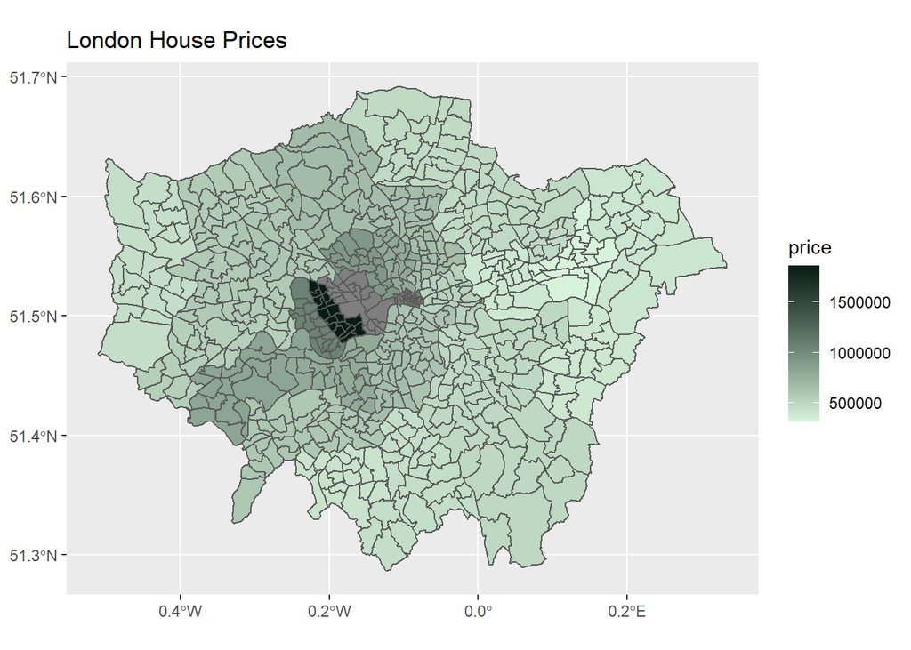

```r
ggplot(data = train_price_map, aes(fill = price)) +
   geom_sf() +
   scale_fill_gradient(low = "#d8f3dc", high = "#081c15") +
   labs(title="London House Prices")
```

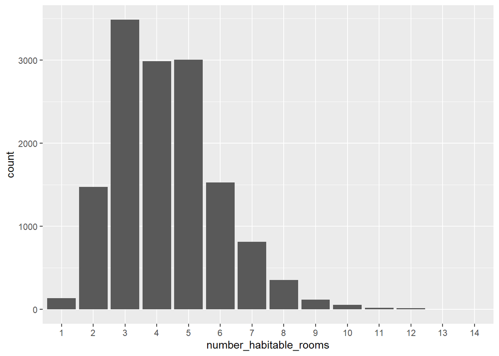

```r
# distribution of number_habitable_rooms
training_d %>%
  ggplot() + geom_bar(aes(x=number_habitable_rooms))
```